[figure not shown]

[Home](https://adamdennett.github.io/school_attainment_tool/) [GitHub](https://github.com/adamdennett/school_attainment_tool)

# Financial Model Experiments

Do school financial variables improve the attainment models?

Published

March 19, 2026

```r
library(tidyverse)
library(lme4)
library(lmerTest)
library(performance)
library(knitr)
library(scales)
library(patchwork)
library(here)

source(here::here("R", "helpers.R"))
```

# 1 Overview

This document takes the baseline multilevel models from `model_experiments.qmd` and systematically tests whether adding school-level financial variables (from CFR/AAR returns) improves model fit.

The baseline model predicts `log(ATT8SCR)` using 9 fixed effects with nested random intercepts for year, Ofsted rating, and region/LA:

$$\log(\text{ATT8}) \sim \text{9 predictors} + (1|\text{year}) + (1|\text{Ofsted}) + (1|\text{region/LA})$$

We test financial variables one at a time, then in combination, comparing marginal and conditional $R^2$.

# 2 Data Preparation

```r
# Load the main panel (has gorard_segregation, OFSTEDRATING_1, fin_* cols, etc.)
panel <- readRDS(here::here("data", "panel_data.rds"))

# Supplement with per-pupil columns not carried by 03a_add_finance.R
finance <- readRDS(here::here("data", "financial_returns.rds"))
finance_extra <- finance %>%
  transmute(URN, academic_year,
            fin_premises_costs_pp = premises_costs_pp)
panel <- panel %>%
  left_join(finance_extra, by = c("URN", "academic_year"))

cat("Panel:", nrow(panel), "rows\n")
```

```
Panel: 16174 rows
```

```r
cat("Financial match:", sum(!is.na(panel$fin_total_income_pp)), "/", nrow(panel), "\n")
```

```
Financial match: 10204 / 16174
```

## 2.1 Model dataset

```r
model_data <- panel %>%
  filter(MINORGROUP %in% c("Academy", "Maintained school")) %>%
  filter(
    !is.na(ATT8SCR), ATT8SCR > 0,
    PTFSM6CLA1A > 0, PERCTOT > 0, PNUMEAL > 0,
    !is.na(OFSTEDRATING_1), !is.na(gor_name), !is.na(LANAME),
    !is.na(remained_in_the_same_school),
    !is.na(teachers_on_leadership_pay_range_percent),
    average_number_of_days_taken > 0,
    !is.na(gorard_segregation)
  ) %>%
  mutate(
    OFSTEDRATING_1 = factor(OFSTEDRATING_1,
                            levels = c("Outstanding", "Good",
                                       "Requires Improvement", "Inadequate"),
                            ordered = TRUE),
    gor_name   = factor(gor_name),
    LANAME     = factor(LANAME),
    year_label = factor(year_label)
  ) %>%
  droplevels()

contrasts(model_data$OFSTEDRATING_1) <-
  contr.treatment(levels(model_data$OFSTEDRATING_1))

cat("Full model dataset:", nrow(model_data), "rows\n")
```

```
Full model dataset: 12210 rows
```

```r
cat("Years:", paste(levels(model_data$year_label), collapse = ", "), "\n")
```

```
Years: 2021-22, 2022-23, 2023-24, 2024-25
```

```r
cat("With financial data:", sum(!is.na(model_data$fin_total_income_pp)), "\n")
```

```
With financial data: 9554
```

```r
# Dataset with complete financial data for fair comparison
d_fin <- model_data %>%
  filter(
    !is.na(fin_total_income_pp), fin_total_income_pp > 0,
    !is.na(fin_staff_income_ratio),
    !is.na(fin_balance_income_ratio)
  ) %>%
  droplevels()

contrasts(d_fin$OFSTEDRATING_1) <-
  contr.treatment(levels(d_fin$OFSTEDRATING_1))

cat("Model dataset with financial data:", nrow(d_fin), "rows\n")
```

```
Model dataset with financial data: 9548 rows
```

```r
cat("Years:", paste(sort(unique(as.character(d_fin$year_label))), collapse = ", "), "\n")
```

```
Years: 2021-22, 2022-23, 2023-24, 2024-25
```

```r
cat("LAs:", n_distinct(d_fin$LANAME), "\n")
```

```
LAs: 152
```

## 2.2 Candidate financial variables

```r
d_fin %>%
  summarise(
    across(
      starts_with("fin_") & where(is.numeric),
      list(
        n = ~sum(!is.na(.x)),
        Median = ~median(.x, na.rm = TRUE),
        SD = ~sd(.x, na.rm = TRUE)
      ),
      .names = "{.col}|{.fn}"
    )
  ) %>%
  pivot_longer(everything(), names_to = c("Variable", "Stat"), names_sep = "\\|") %>%
  pivot_wider(names_from = Stat, values_from = value) %>%
  mutate(
    Label = var_label(Variable),
    Median = round(Median, 2),
    SD = round(SD, 2),
    n = comma(n)
  ) %>%
  select(Variable, Label, n, Median, SD) %>%
  kable()
```

Table 1: Financial variables available for model experiments

| Variable | Label | n | Median | SD |
| --- | --- | --- | --- | --- |
| fin_total_income | Total income (£) | 9,548 | 7780000.00 | 2925063.78 |
| fin_total_expenditure | Total expenditure (£) | 9,548 | 7450867.50 | 2873014.47 |
| fin_in_year_balance | In-year balance (£) | 9,548 | 228000.00 | 653071.57 |
| fin_revenue_reserve | Revenue reserve (£) | 9,548 | 505000.04 | 1131603.35 |
| fin_grant_funding | Grant funding (£) | 9,548 | 7562000.00 | 2815213.81 |
| fin_self_generated | Self-generated income (£) | 9,548 | 229509.50 | 424411.14 |
| fin_staff_costs | Total staff costs (£) | 9,548 | 5609000.00 | 2171065.82 |
| fin_teaching_staff | Teaching staff costs (£) | 8,926 | 4102546.00 | 1648305.11 |
| fin_premises_costs | Premises costs (£) | 9,548 | 416514.00 | 394619.97 |
| fin_energy | Energy costs (£) | 8,926 | 159000.00 | 108866.84 |
| fin_pupil_premium | Pupil premium income (£) | 1,685 | 275598.00 | 146758.69 |
| fin_total_income_pp | Total income per pupil (£) | 9,548 | 7208.88 | 1311.94 |
| fin_total_expenditure_pp | Total expenditure per pupil (£) | 9,548 | 6922.25 | 1379.05 |
| fin_staff_costs_pp | Staff costs per pupil (£) | 9,548 | 5210.32 | 979.37 |
| fin_teaching_staff_pp | Teaching staff costs per pupil (£) | 8,926 | 3806.37 | 736.47 |
| fin_grant_funding_pp | Grant funding per pupil (£) | 9,548 | 6985.92 | 1239.12 |
| fin_staff_income_ratio | Staff costs as % of income | 9,548 | 0.73 | 0.15 |
| fin_teaching_expenditure_ratio | Teaching staff as % of expenditure | 8,916 | 0.55 | 0.07 |
| fin_balance_income_ratio | In-year balance as % of income | 9,548 | 0.03 | 0.20 |
| fin_premises_costs_pp | fin_premises_costs_pp | 9,548 | 394.93 | 320.94 |

# 3 Baseline Model (no financial variables)

This exactly replicates Analysis A “All Pupils” from `model_experiments.qmd`, but fitted on the financial-data-complete subset for fair comparison.

```r
mod_baseline <- lmer(
  log(ATT8SCR) ~
    log(PTFSM6CLA1A) + log(PERCTOT) + log(PNUMEAL) +
    PTPRIORLO + ADMPOL_PT + gorard_segregation +
    remained_in_the_same_school +
    teachers_on_leadership_pay_range_percent +
    log(average_number_of_days_taken) +
    (1 | year_label) + (1 | OFSTEDRATING_1) + (1 | gor_name/LANAME),
  data = d_fin,
  REML = TRUE,
  na.action = na.exclude,
  control = lmerControl(optimizer = "bobyqa", optCtrl = list(maxfun = 20000))
)

r2_baseline <- r2(mod_baseline)
cat("Baseline R² (marginal):", round(r2_baseline$R2_marginal, 4), "\n")
```

```
Baseline R² (marginal): 0.6454
```

```r
cat("Baseline R² (conditional):", round(r2_baseline$R2_conditional, 4), "\n")
```

```
Baseline R² (conditional): 0.7904
```

```r
cat("Singular?", isSingular(mod_baseline), "\n")
```

```
Singular? FALSE
```

# 4 Single-Variable Additions

Each financial variable is added one at a time to the baseline model. We compare the change in marginal and conditional $R^2$.

```r
# Define candidate additions
# Per-pupil vars are log-transformed; ratios are left linear
candidates <- list(
  "log(fin_total_income_pp)"          = "Total income pp (log)",
  "log(fin_total_expenditure_pp)"     = "Total expenditure pp (log)",
  "log(fin_staff_costs_pp)"           = "Staff costs pp (log)",
  "log(fin_teaching_staff_pp)"        = "Teaching staff pp (log)",
  "log(fin_grant_funding_pp)"         = "Grant funding pp (log)",
  "log(fin_premises_costs_pp)"        = "Premises costs pp (log)",
  "fin_staff_income_ratio"            = "Staff/income ratio",
  "fin_teaching_expenditure_ratio"    = "Teaching/expenditure ratio",
  "fin_balance_income_ratio"          = "Balance/income ratio"
)

base_formula <- log(ATT8SCR) ~
  log(PTFSM6CLA1A) + log(PERCTOT) + log(PNUMEAL) +
  PTPRIORLO + ADMPOL_PT + gorard_segregation +
  remained_in_the_same_school +
  teachers_on_leadership_pay_range_percent +
  log(average_number_of_days_taken) +
  (1 | year_label) + (1 | OFSTEDRATING_1) + (1 | gor_name/LANAME)

results <- tibble(
  term = character(),
  label = character(),
  r2_marginal = numeric(),
  r2_conditional = numeric(),
  delta_marginal = numeric(),
  delta_conditional = numeric(),
  coef = numeric(),
  se = numeric(),
  p_value = numeric(),
  singular = logical()
)

# Fit each candidate
for (term in names(candidates)) {

  # Build extended formula
  ext_formula <- update(base_formula, paste("~ . +", term))

  # Filter for valid values of the candidate
  # (log-transformed vars need > 0)
  d_sub <- d_fin
  if (grepl("^log\\(", term)) {
    inner_var <- gsub("^log\\((.+)\\)$", "\\1", term)
    d_sub <- d_sub %>% filter(!is.na(.data[[inner_var]]), .data[[inner_var]] > 0)
  } else {
    d_sub <- d_sub %>% filter(!is.na(.data[[term]]), is.finite(.data[[term]]))
  }
  d_sub <- droplevels(d_sub)
  contrasts(d_sub$OFSTEDRATING_1) <- contr.treatment(levels(d_sub$OFSTEDRATING_1))

  tryCatch({
    mod <- lmer(
      ext_formula, data = d_sub, REML = TRUE, na.action = na.exclude,
      control = lmerControl(optimizer = "bobyqa", optCtrl = list(maxfun = 20000))
    )

    r2_ext <- r2(mod)
    coefs <- summary(mod)$coefficients

    # Find the row for our added term
    term_clean <- term
    row_match <- grep(gsub("[()]", "", term), rownames(coefs), fixed = FALSE)
    if (length(row_match) == 0) row_match <- nrow(coefs)

    results <- bind_rows(results, tibble(
      term = term,
      label = candidates[[term]],
      r2_marginal = r2_ext$R2_marginal,
      r2_conditional = r2_ext$R2_conditional,
      delta_marginal = r2_ext$R2_marginal - r2_baseline$R2_marginal,
      delta_conditional = r2_ext$R2_conditional - r2_baseline$R2_conditional,
      coef = coefs[row_match[1], "Estimate"],
      se = coefs[row_match[1], "Std. Error"],
      p_value = coefs[row_match[1], "Pr(>|t|)"],
      singular = isSingular(mod)
    ))

  }, error = function(e) {
    message("  Failed: ", term, " — ", e$message)
  })
}
```

## 4.1 Results

```r
results %>%
  mutate(
    `R² (m)` = sprintf("%.4f", r2_marginal),
    `R² (c)` = sprintf("%.4f", r2_conditional),
    `ΔR² (m)` = sprintf("%+.4f", delta_marginal),
    `ΔR² (c)` = sprintf("%+.4f", delta_conditional),
    Coef = sprintf("%.4f", coef),
    SE = sprintf("%.4f", se),
    p = case_when(
      p_value < 0.001 ~ "< 0.001",
      p_value < 0.01  ~ sprintf("%.3f", p_value),
      p_value < 0.05  ~ sprintf("%.3f", p_value),
      TRUE            ~ sprintf("%.3f", p_value)
    ),
    Sig = case_when(
      p_value < 0.001 ~ "***",
      p_value < 0.01  ~ "**",
      p_value < 0.05  ~ "*",
      p_value < 0.1   ~ ".",
      TRUE            ~ ""
    )
  ) %>%
  select(Variable = label, `R² (m)`, `R² (c)`, `ΔR² (m)`, `ΔR² (c)`,
         Coef, SE, p, Sig) %>%
  kable()
```

Table 2: Effect of adding each financial variable to the baseline model

| Variable | R² (m) | R² (c) | ΔR² (m) | ΔR² (c) | Coef | SE | p | Sig |
| --- | --- | --- | --- | --- | --- | --- | --- | --- |
| Total income pp (log) | 0.6465 | 0.7896 | +0.0011 | -0.0008 | -0.0199 | 0.0058 | < 0.001 | *** |
| Total expenditure pp (log) | 0.6469 | 0.7895 | +0.0014 | -0.0008 | -0.0163 | 0.0051 | 0.001 | ** |
| Staff costs pp (log) | 0.6462 | 0.7899 | +0.0008 | -0.0005 | -0.0093 | 0.0038 | 0.016 | * |
| Teaching staff pp (log) | 0.6514 | 0.7976 | +0.0060 | +0.0072 | 0.0048 | 0.0050 | 0.330 |  |
| Grant funding pp (log) | 0.6467 | 0.7894 | +0.0013 | -0.0010 | -0.0245 | 0.0063 | < 0.001 | *** |
| Premises costs pp (log) | 0.6449 | 0.7895 | -0.0006 | -0.0008 | -0.0011 | 0.0015 | 0.462 |  |
| Staff/income ratio | 0.6454 | 0.7904 | -0.0001 | -0.0000 | 0.0031 | 0.0061 | 0.611 |  |
| Teaching/expenditure ratio | 0.6539 | 0.7976 | +0.0084 | +0.0072 | 0.0689 | 0.0149 | < 0.001 | *** |
| Balance/income ratio | 0.6454 | 0.7904 | -0.0000 | -0.0000 | -0.0008 | 0.0045 | 0.854 |  |

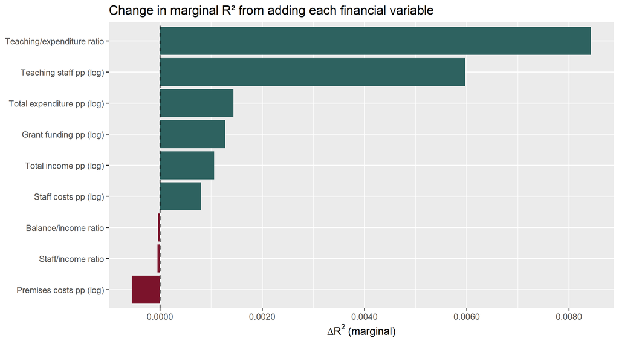

Figure 1: Change in marginal R² from adding each financial variable

```r
results %>%
  mutate(label = fct_reorder(label, delta_marginal)) %>%
  ggplot(aes(delta_marginal, label)) +
  geom_col(aes(fill = delta_marginal > 0), show.legend = FALSE) +
  geom_vline(xintercept = 0, linetype = "dashed") +
  scale_fill_manual(values = c(`TRUE` = "#2e6260", `FALSE` = "#7b132b")) +
  scale_x_continuous(labels = label_number(accuracy = 0.0001)) +
  labs(x = expression(Delta * R^2 ~ "(marginal)"),
       y = NULL,
       title = "Change in marginal R² from adding each financial variable")
```

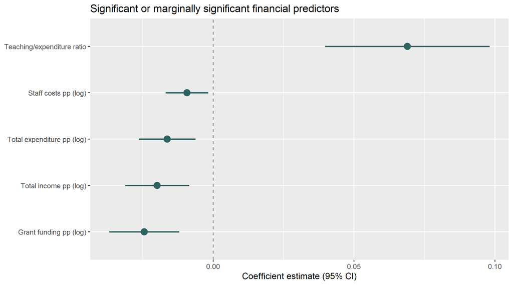

Figure 2: Coefficient estimates and 95% CIs for financial variable additions

```r
results %>%
  filter(p_value < 0.1) %>%
  mutate(
    label = fct_reorder(label, coef),
    lower = coef - 1.96 * se,
    upper = coef + 1.96 * se
  ) %>%
  ggplot(aes(coef, label)) +
  geom_vline(xintercept = 0, linetype = "dashed", colour = "grey50") +
  geom_pointrange(aes(xmin = lower, xmax = upper), colour = "#2e6260",
                  linewidth = 0.8, size = 0.8) +
  labs(x = "Coefficient estimate (95% CI)", y = NULL,
       title = "Significant or marginally significant financial predictors")
```

# 5 Multi-Variable Models

Based on the single-variable results, we test combinations of the most promising financial variables.

```r
# Select variables that improved marginal R² or were significant
sig_vars <- results %>%
  filter(p_value < 0.05, delta_marginal > 0) %>%
  arrange(desc(delta_marginal))

cat("Significant improvers (p < 0.05, positive ΔR²):\n")
```

```
Significant improvers (p < 0.05, positive ΔR²):
```

```r
for (i in seq_len(nrow(sig_vars))) {
  cat(sprintf("  %s: ΔR²(m) = %+.4f, coef = %.4f, p = %.4f\n",
              sig_vars$label[i], sig_vars$delta_marginal[i],
              sig_vars$coef[i], sig_vars$p_value[i]))
}
```

```
  Teaching/expenditure ratio: ΔR²(m) = +0.0084, coef = 0.0689, p = 0.0000
  Total expenditure pp (log): ΔR²(m) = +0.0014, coef = -0.0163, p = 0.0015
  Grant funding pp (log): ΔR²(m) = +0.0013, coef = -0.0245, p = 0.0001
  Total income pp (log): ΔR²(m) = +0.0011, coef = -0.0199, p = 0.0006
  Staff costs pp (log): ΔR²(m) = +0.0008, coef = -0.0093, p = 0.0157
```

## 5.1 Model with all significant financial variables

```r
if (nrow(sig_vars) > 0) {
  # Build formula with all significant vars
  fin_terms <- paste(sig_vars$term, collapse = " + ")
  multi_formula <- update(base_formula, paste("~ . +", fin_terms))

  # Filter data
  d_multi <- d_fin
  for (term in sig_vars$term) {
    if (grepl("^log\\(", term)) {
      inner_var <- gsub("^log\\((.+)\\)$", "\\1", term)
      d_multi <- d_multi %>% filter(!is.na(.data[[inner_var]]), .data[[inner_var]] > 0)
    } else {
      d_multi <- d_multi %>% filter(!is.na(.data[[term]]), is.finite(.data[[term]]))
    }
  }
  d_multi <- droplevels(d_multi)
  contrasts(d_multi$OFSTEDRATING_1) <- contr.treatment(levels(d_multi$OFSTEDRATING_1))

  mod_multi <- lmer(
    multi_formula, data = d_multi, REML = TRUE, na.action = na.exclude,
    control = lmerControl(optimizer = "bobyqa", optCtrl = list(maxfun = 20000))
  )

  r2_multi <- r2(mod_multi)
  cat("Combined model R² (marginal):", round(r2_multi$R2_marginal, 4), "\n")
  cat("Combined model R² (conditional):", round(r2_multi$R2_conditional, 4), "\n")
  cat("Baseline R² (marginal):", round(r2_baseline$R2_marginal, 4), "\n")
  cat("Improvement:", sprintf("%+.4f", r2_multi$R2_marginal - r2_baseline$R2_marginal), "\n")
  cat("Singular?", isSingular(mod_multi), "\n")
  cat("Observations:", nrow(d_multi), "\n\n")

  summary(mod_multi)
} else {
  cat("No financial variables significantly improved the baseline model.\n")
}
```

```
Combined model R² (marginal): 0.6552
Combined model R² (conditional): 0.7972
Baseline R² (marginal): 0.6454
Improvement: +0.0097
Singular? FALSE
Observations: 8916
```

```
Linear mixed model fit by REML. t-tests use Satterthwaite's method [
lmerModLmerTest]
Formula: multi_formula
   Data: d_multi
Control: lmerControl(optimizer = "bobyqa", optCtrl = list(maxfun = 20000))

REML criterion at convergence: -17708.4

Scaled residuals:
    Min      1Q  Median      3Q     Max
-48.736  -0.483   0.024   0.542   5.276

Random effects:
 Groups          Name        Variance  Std.Dev.
 LANAME:gor_name (Intercept) 0.0008404 0.02899
 gor_name        (Intercept) 0.0002928 0.01711
 OFSTEDRATING_1  (Intercept) 0.0022490 0.04742
 year_label      (Intercept) 0.0019534 0.04420
 Residual                    0.0076204 0.08729
Number of obs: 8916, groups:
LANAME:gor_name, 152; gor_name, 9; OFSTEDRATING_1, 4; year_label, 4

Fixed effects:
                                           Estimate Std. Error         df
(Intercept)                               4.730e+00  6.926e-02  1.215e+02
log(PTFSM6CLA1A)                         -6.569e-02  2.979e-03  8.024e+03
log(PERCTOT)                             -2.098e-01  5.148e-03  8.888e+03
log(PNUMEAL)                              7.277e-03  1.283e-03  6.910e+03
PTPRIORLO                                -5.879e-03  1.511e-04  8.662e+03
ADMPOL_PTOTHER NON SEL                   -1.520e-03  7.727e-03  1.430e+03
ADMPOL_PTSEL                              1.037e-01  7.215e-03  8.376e+03
gorard_segregation                       -7.739e-02  4.947e-02  4.592e+02
remained_in_the_same_school               3.892e-04  5.349e-05  8.844e+03
teachers_on_leadership_pay_range_percent -1.314e-03  2.213e-04  8.872e+03
log(average_number_of_days_taken)        -1.486e-02  2.571e-03  8.838e+03
fin_teaching_expenditure_ratio            1.014e-01  1.884e-02  8.872e+03
log(fin_total_expenditure_pp)             3.992e-02  1.712e-02  8.855e+03
log(fin_grant_funding_pp)                -3.488e-02  1.690e-02  8.869e+03
log(fin_total_income_pp)                  6.436e-03  1.654e-02  8.838e+03
log(fin_staff_costs_pp)                  -2.904e-02  9.929e-03  8.835e+03
                                         t value Pr(>|t|)
(Intercept)                               68.294  < 2e-16 ***
log(PTFSM6CLA1A)                         -22.055  < 2e-16 ***
log(PERCTOT)                             -40.746  < 2e-16 ***
log(PNUMEAL)                               5.673 1.46e-08 ***
PTPRIORLO                                -38.899  < 2e-16 ***
ADMPOL_PTOTHER NON SEL                    -0.197  0.84410
ADMPOL_PTSEL                              14.377  < 2e-16 ***
gorard_segregation                        -1.564  0.11845
remained_in_the_same_school                7.277 3.69e-13 ***
teachers_on_leadership_pay_range_percent  -5.939 2.98e-09 ***
log(average_number_of_days_taken)         -5.781 7.67e-09 ***
fin_teaching_expenditure_ratio             5.384 7.49e-08 ***
log(fin_total_expenditure_pp)              2.332  0.01970 *
log(fin_grant_funding_pp)                 -2.064  0.03901 *
log(fin_total_income_pp)                   0.389  0.69711
log(fin_staff_costs_pp)                   -2.925  0.00346 **
---
Signif. codes:  0 '***' 0.001 '**' 0.01 '*' 0.05 '.' 0.1 ' ' 1
```

# 6 Disadvantaged Pupils

Do financial variables help predict outcomes for **disadvantaged** pupils specifically?

```r
d_disadv <- d_fin %>%
  filter(!is.na(ATT8SCR_FSM6CLA1A), ATT8SCR_FSM6CLA1A > 0) %>%
  droplevels()
contrasts(d_disadv$OFSTEDRATING_1) <- contr.treatment(levels(d_disadv$OFSTEDRATING_1))

mod_disadv_base <- lmer(
  log(ATT8SCR_FSM6CLA1A) ~
    log(PTFSM6CLA1A) + log(PERCTOT) + log(PNUMEAL) +
    PTPRIORLO + ADMPOL_PT + gorard_segregation +
    remained_in_the_same_school +
    teachers_on_leadership_pay_range_percent +
    log(average_number_of_days_taken) +
    (1 | year_label) + (1 | OFSTEDRATING_1) + (1 | gor_name/LANAME),
  data = d_disadv, REML = TRUE, na.action = na.exclude,
  control = lmerControl(optimizer = "bobyqa", optCtrl = list(maxfun = 20000))
)

r2_disadv_base <- r2(mod_disadv_base)
cat("Disadvantaged baseline R² (m):", round(r2_disadv_base$R2_marginal, 4), "\n")
```

```
Disadvantaged baseline R² (m): 0.5461
```

```r
cat("Disadvantaged baseline R² (c):", round(r2_disadv_base$R2_conditional, 4), "\n")
```

```
Disadvantaged baseline R² (c): 0.7206
```

```r
results_disadv <- tibble(
  term = character(), label = character(),
  r2_marginal = numeric(), r2_conditional = numeric(),
  delta_marginal = numeric(), delta_conditional = numeric(),
  coef = numeric(), se = numeric(), p_value = numeric()
)

disadv_base_formula <- log(ATT8SCR_FSM6CLA1A) ~
  log(PTFSM6CLA1A) + log(PERCTOT) + log(PNUMEAL) +
  PTPRIORLO + ADMPOL_PT + gorard_segregation +
  remained_in_the_same_school +
  teachers_on_leadership_pay_range_percent +
  log(average_number_of_days_taken) +
  (1 | year_label) + (1 | OFSTEDRATING_1) + (1 | gor_name/LANAME)

for (term in names(candidates)) {
  ext_formula <- update(disadv_base_formula, paste("~ . +", term))

  d_sub <- d_disadv
  if (grepl("^log\\(", term)) {
    inner_var <- gsub("^log\\((.+)\\)$", "\\1", term)
    d_sub <- d_sub %>% filter(!is.na(.data[[inner_var]]), .data[[inner_var]] > 0)
  } else {
    d_sub <- d_sub %>% filter(!is.na(.data[[term]]), is.finite(.data[[term]]))
  }
  d_sub <- droplevels(d_sub)
  contrasts(d_sub$OFSTEDRATING_1) <- contr.treatment(levels(d_sub$OFSTEDRATING_1))

  tryCatch({
    mod <- lmer(
      ext_formula, data = d_sub, REML = TRUE, na.action = na.exclude,
      control = lmerControl(optimizer = "bobyqa", optCtrl = list(maxfun = 20000))
    )
    r2_ext <- r2(mod)
    coefs <- summary(mod)$coefficients
    row_match <- grep(gsub("[()]", "", term), rownames(coefs), fixed = FALSE)
    if (length(row_match) == 0) row_match <- nrow(coefs)

    results_disadv <- bind_rows(results_disadv, tibble(
      term = term, label = candidates[[term]],
      r2_marginal = r2_ext$R2_marginal, r2_conditional = r2_ext$R2_conditional,
      delta_marginal = r2_ext$R2_marginal - r2_disadv_base$R2_marginal,
      delta_conditional = r2_ext$R2_conditional - r2_disadv_base$R2_conditional,
      coef = coefs[row_match[1], "Estimate"],
      se = coefs[row_match[1], "Std. Error"],
      p_value = coefs[row_match[1], "Pr(>|t|)"]
    ))
  }, error = function(e) message("  Failed: ", term))
}
```

```r
results_disadv %>%
  mutate(
    `R² (m)` = sprintf("%.4f", r2_marginal),
    `ΔR² (m)` = sprintf("%+.4f", delta_marginal),
    Coef = sprintf("%.4f", coef),
    p = case_when(
      p_value < 0.001 ~ "< 0.001",
      TRUE ~ sprintf("%.3f", p_value)
    ),
    Sig = case_when(
      p_value < 0.001 ~ "***", p_value < 0.01 ~ "**",
      p_value < 0.05 ~ "*", p_value < 0.1 ~ ".", TRUE ~ ""
    )
  ) %>%
  select(Variable = label, `R² (m)`, `ΔR² (m)`, Coef, p, Sig) %>%
  kable()
```

Table 3: Financial variable effects on disadvantaged pupil attainment

| Variable | R² (m) | ΔR² (m) | Coef | p | Sig |
| --- | --- | --- | --- | --- | --- |
| Total income pp (log) | 0.5461 | -0.0000 | 0.0008 | 0.913 |  |
| Total expenditure pp (log) | 0.5463 | +0.0001 | -0.0010 | 0.888 |  |
| Staff costs pp (log) | 0.5463 | +0.0001 | -0.0030 | 0.574 |  |
| Teaching staff pp (log) | 0.5495 | +0.0033 | 0.0167 | 0.012 | * |
| Grant funding pp (log) | 0.5461 | -0.0000 | -0.0010 | 0.904 |  |
| Premises costs pp (log) | 0.5457 | -0.0005 | -0.0015 | 0.432 |  |
| Staff/income ratio | 0.5462 | +0.0000 | -0.0016 | 0.839 |  |
| Teaching/expenditure ratio | 0.5509 | +0.0047 | 0.0732 | < 0.001 | *** |
| Balance/income ratio | 0.5461 | -0.0001 | -0.0012 | 0.840 |  |

# 7 Non-Disadvantaged Pupils

```r
d_nondisadv <- d_fin %>%
  filter(!is.na(ATT8SCR_NFSM6CLA1A), ATT8SCR_NFSM6CLA1A > 0) %>%
  droplevels()
contrasts(d_nondisadv$OFSTEDRATING_1) <- contr.treatment(levels(d_nondisadv$OFSTEDRATING_1))

mod_nondisadv_base <- lmer(
  log(ATT8SCR_NFSM6CLA1A) ~
    log(PTFSM6CLA1A) + log(PERCTOT) + log(PNUMEAL) +
    PTPRIORLO + ADMPOL_PT + gorard_segregation +
    remained_in_the_same_school +
    teachers_on_leadership_pay_range_percent +
    log(average_number_of_days_taken) +
    (1 | year_label) + (1 | OFSTEDRATING_1) + (1 | gor_name/LANAME),
  data = d_nondisadv, REML = TRUE, na.action = na.exclude,
  control = lmerControl(optimizer = "bobyqa", optCtrl = list(maxfun = 20000))
)

r2_nondisadv_base <- r2(mod_nondisadv_base)
cat("Non-disadvantaged baseline R² (m):", round(r2_nondisadv_base$R2_marginal, 4), "\n")
```

```
Non-disadvantaged baseline R² (m): 0.6131
```

```r
cat("Non-disadvantaged baseline R² (c):", round(r2_nondisadv_base$R2_conditional, 4), "\n")
```

```
Non-disadvantaged baseline R² (c): 0.7881
```

```r
results_nondisadv <- tibble(
  term = character(), label = character(),
  r2_marginal = numeric(), r2_conditional = numeric(),
  delta_marginal = numeric(), delta_conditional = numeric(),
  coef = numeric(), se = numeric(), p_value = numeric()
)

nondisadv_base_formula <- log(ATT8SCR_NFSM6CLA1A) ~
  log(PTFSM6CLA1A) + log(PERCTOT) + log(PNUMEAL) +
  PTPRIORLO + ADMPOL_PT + gorard_segregation +
  remained_in_the_same_school +
  teachers_on_leadership_pay_range_percent +
  log(average_number_of_days_taken) +
  (1 | year_label) + (1 | OFSTEDRATING_1) + (1 | gor_name/LANAME)

for (term in names(candidates)) {
  ext_formula <- update(nondisadv_base_formula, paste("~ . +", term))

  d_sub <- d_nondisadv
  if (grepl("^log\\(", term)) {
    inner_var <- gsub("^log\\((.+)\\)$", "\\1", term)
    d_sub <- d_sub %>% filter(!is.na(.data[[inner_var]]), .data[[inner_var]] > 0)
  } else {
    d_sub <- d_sub %>% filter(!is.na(.data[[term]]), is.finite(.data[[term]]))
  }
  d_sub <- droplevels(d_sub)
  contrasts(d_sub$OFSTEDRATING_1) <- contr.treatment(levels(d_sub$OFSTEDRATING_1))

  tryCatch({
    mod <- lmer(
      ext_formula, data = d_sub, REML = TRUE, na.action = na.exclude,
      control = lmerControl(optimizer = "bobyqa", optCtrl = list(maxfun = 20000))
    )
    r2_ext <- r2(mod)
    coefs <- summary(mod)$coefficients
    row_match <- grep(gsub("[()]", "", term), rownames(coefs), fixed = FALSE)
    if (length(row_match) == 0) row_match <- nrow(coefs)

    results_nondisadv <- bind_rows(results_nondisadv, tibble(
      term = term, label = candidates[[term]],
      r2_marginal = r2_ext$R2_marginal, r2_conditional = r2_ext$R2_conditional,
      delta_marginal = r2_ext$R2_marginal - r2_nondisadv_base$R2_marginal,
      delta_conditional = r2_ext$R2_conditional - r2_nondisadv_base$R2_conditional,
      coef = coefs[row_match[1], "Estimate"],
      se = coefs[row_match[1], "Std. Error"],
      p_value = coefs[row_match[1], "Pr(>|t|)"]
    ))
  }, error = function(e) message("  Failed: ", term))
}
```

```r
results_nondisadv %>%
  mutate(
    `R² (m)` = sprintf("%.4f", r2_marginal),
    `ΔR² (m)` = sprintf("%+.4f", delta_marginal),
    Coef = sprintf("%.4f", coef),
    p = case_when(
      p_value < 0.001 ~ "< 0.001",
      TRUE ~ sprintf("%.3f", p_value)
    ),
    Sig = case_when(
      p_value < 0.001 ~ "***", p_value < 0.01 ~ "**",
      p_value < 0.05 ~ "*", p_value < 0.1 ~ ".", TRUE ~ ""
    )
  ) %>%
  select(Variable = label, `R² (m)`, `ΔR² (m)`, Coef, p, Sig) %>%
  kable()
```

Table 4: Financial variable effects on non-disadvantaged pupil attainment

| Variable | R² (m) | ΔR² (m) | Coef | p | Sig |
| --- | --- | --- | --- | --- | --- |
| Total income pp (log) | 0.6137 | +0.0005 | -0.0131 | 0.007 | ** |
| Total expenditure pp (log) | 0.6142 | +0.0011 | -0.0121 | 0.005 | ** |
| Staff costs pp (log) | 0.6138 | +0.0007 | -0.0074 | 0.028 | * |
| Teaching staff pp (log) | 0.6171 | +0.0039 | 0.0025 | 0.554 |  |
| Grant funding pp (log) | 0.6139 | +0.0008 | -0.0177 | < 0.001 | *** |
| Premises costs pp (log) | 0.6133 | +0.0001 | 0.0008 | 0.517 |  |
| Staff/income ratio | 0.6131 | -0.0000 | 0.0007 | 0.895 |  |
| Teaching/expenditure ratio | 0.6181 | +0.0050 | 0.0369 | 0.004 | ** |
| Balance/income ratio | 0.6131 | +0.0000 | 0.0008 | 0.830 |  |

# 8 Comparison Across Outcomes

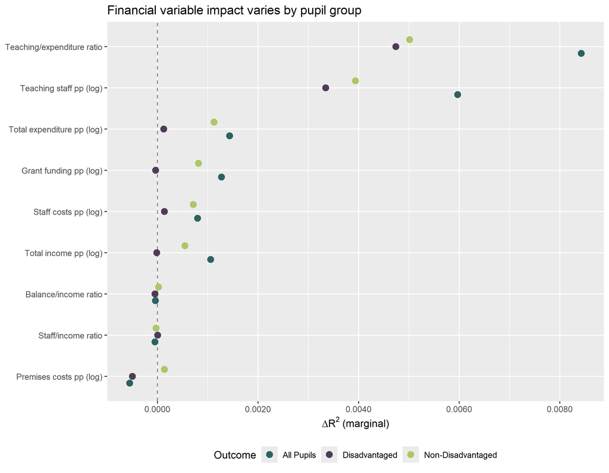

Figure 3: Change in marginal R² by outcome group

```r
all_results <- bind_rows(
  results %>% mutate(outcome = "All Pupils"),
  results_disadv %>% mutate(outcome = "Disadvantaged"),
  results_nondisadv %>% mutate(outcome = "Non-Disadvantaged")
)

all_results %>%
  mutate(label = fct_reorder(label, delta_marginal, .fun = mean)) %>%
  ggplot(aes(delta_marginal, label, colour = outcome)) +
  geom_vline(xintercept = 0, linetype = "dashed", colour = "grey50") +
  geom_point(size = 3, position = position_dodge(width = 0.5)) +
  scale_colour_manual(values = c("#2e6260", "#4e3c56", "#abc766", "#e16fca", "#f9dd73"), name = "Outcome") +
  scale_x_continuous(labels = label_number(accuracy = 0.0001)) +
  labs(x = expression(Delta * R^2 ~ "(marginal)"), y = NULL,
       title = "Financial variable impact varies by pupil group") +
  theme(legend.position = "bottom")
```

```r
all_results %>%
  mutate(
    sig = case_when(
      p_value < 0.001 ~ "***",
      p_value < 0.01  ~ "**",
      p_value < 0.05  ~ "*",
      p_value < 0.1   ~ ".",
      TRUE            ~ ""
    ),
    cell = paste0(sprintf("%+.4f", delta_marginal), " ", sig)
  ) %>%
  select(Variable = label, outcome, cell) %>%
  pivot_wider(names_from = outcome, values_from = cell) %>%
  kable()
```

Table 5: Significance of financial variables across all three outcomes

| Variable | All Pupils | Disadvantaged | Non-Disadvantaged |
| --- | --- | --- | --- |
| Total income pp (log) | +0.0011 *** | -0.0000 | +0.0005 ** |
| Total expenditure pp (log) | +0.0014 ** | +0.0001 | +0.0011 ** |
| Staff costs pp (log) | +0.0008 * | +0.0001 | +0.0007 * |
| Teaching staff pp (log) | +0.0060 | +0.0033 * | +0.0039 |
| Grant funding pp (log) | +0.0013 *** | -0.0000 | +0.0008 *** |
| Premises costs pp (log) | -0.0006 | -0.0005 | +0.0001 |
| Staff/income ratio | -0.0001 | +0.0000 | -0.0000 |
| Teaching/expenditure ratio | +0.0084 *** | +0.0047 *** | +0.0050 ** |
| Balance/income ratio | -0.0000 | -0.0001 | +0.0000 |

# 9 Best Combined Model (if improvements found)

```r
# Collect all significant improvers across all outcomes
all_sig <- all_results %>%
  filter(p_value < 0.05, delta_marginal > 0)

if (nrow(all_sig) > 0) {
  best_terms <- all_sig %>%
    group_by(term, label) %>%
    summarise(
      mean_delta = mean(delta_marginal),
      n_outcomes = n(),
      .groups = "drop"
    ) %>%
    arrange(desc(n_outcomes), desc(mean_delta))

  cat("Financial variables that significantly improved at least one outcome:\n\n")
  for (i in seq_len(nrow(best_terms))) {
    cat(sprintf("  %s: improved %d/3 outcomes, mean ΔR²(m) = %+.4f\n",
                best_terms$label[i], best_terms$n_outcomes[i],
                best_terms$mean_delta[i]))
  }

  # Fit the best combined model for All Pupils
  cat("\n\n--- Best combined model for All Pupils ---\n\n")

  best_fin_terms <- paste(best_terms$term, collapse = " + ")
  best_formula <- update(base_formula, paste("~ . +", best_fin_terms))

  d_best <- d_fin
  for (term in best_terms$term) {
    if (grepl("^log\\(", term)) {
      inner_var <- gsub("^log\\((.+)\\)$", "\\1", term)
      d_best <- d_best %>% filter(!is.na(.data[[inner_var]]), .data[[inner_var]] > 0)
    } else {
      d_best <- d_best %>% filter(!is.na(.data[[term]]), is.finite(.data[[term]]))
    }
  }
  d_best <- droplevels(d_best)
  contrasts(d_best$OFSTEDRATING_1) <- contr.treatment(levels(d_best$OFSTEDRATING_1))

  mod_best <- lmer(
    best_formula, data = d_best, REML = TRUE, na.action = na.exclude,
    control = lmerControl(optimizer = "bobyqa", optCtrl = list(maxfun = 20000))
  )

  r2_best <- r2(mod_best)
  cat("Best model R² (marginal):", round(r2_best$R2_marginal, 4), "\n")
  cat("Best model R² (conditional):", round(r2_best$R2_conditional, 4), "\n")
  cat("Baseline R² (marginal):", round(r2_baseline$R2_marginal, 4), "\n")
  cat("Total improvement:", sprintf("%+.4f", r2_best$R2_marginal - r2_baseline$R2_marginal), "\n")
  cat("Observations:", nrow(d_best), "\n")
  cat("Singular?", isSingular(mod_best), "\n\n")

  summary(mod_best)
} else {
  cat("No financial variables significantly improved any of the three baseline models.\n")
  cat("This suggests that school-level financial characteristics are largely\n")
  cat("orthogonal to attainment outcomes once the existing predictors\n")
  cat("(deprivation, absence, prior attainment, workforce, segregation)\n")
  cat("are accounted for.\n")
}
```

```
Financial variables that significantly improved at least one outcome:

  Teaching/expenditure ratio: improved 3/3 outcomes, mean ΔR²(m) = +0.0061
  Total expenditure pp (log): improved 2/3 outcomes, mean ΔR²(m) = +0.0013
  Grant funding pp (log): improved 2/3 outcomes, mean ΔR²(m) = +0.0010
  Total income pp (log): improved 2/3 outcomes, mean ΔR²(m) = +0.0008
  Staff costs pp (log): improved 2/3 outcomes, mean ΔR²(m) = +0.0008
  Teaching staff pp (log): improved 1/3 outcomes, mean ΔR²(m) = +0.0033


--- Best combined model for All Pupils ---

Best model R² (marginal): 0.655
Best model R² (conditional): 0.797
Baseline R² (marginal): 0.6454
Total improvement: +0.0095
Observations: 8904
Singular? FALSE
```

```
Linear mixed model fit by REML. t-tests use Satterthwaite's method [
lmerModLmerTest]
Formula: best_formula
   Data: d_best
Control: lmerControl(optimizer = "bobyqa", optCtrl = list(maxfun = 20000))

REML criterion at convergence: -17674.5

Scaled residuals:
    Min      1Q  Median      3Q     Max
-48.712  -0.481   0.024   0.541   5.306

Random effects:
 Groups          Name        Variance  Std.Dev.
 LANAME:gor_name (Intercept) 0.0008395 0.02897
 gor_name        (Intercept) 0.0002931 0.01712
 OFSTEDRATING_1  (Intercept) 0.0022485 0.04742
 year_label      (Intercept) 0.0019563 0.04423
 Residual                    0.0076262 0.08733
Number of obs: 8904, groups:
LANAME:gor_name, 152; gor_name, 9; OFSTEDRATING_1, 4; year_label, 4

Fixed effects:
                                           Estimate Std. Error         df
(Intercept)                               4.752e+00  8.106e-02  2.255e+02
log(PTFSM6CLA1A)                         -6.559e-02  2.990e-03  8.032e+03
log(PERCTOT)                             -2.097e-01  5.152e-03  8.875e+03
log(PNUMEAL)                              7.271e-03  1.285e-03  6.881e+03
PTPRIORLO                                -5.883e-03  1.514e-04  8.643e+03
ADMPOL_PTOTHER NON SEL                   -1.131e-03  7.734e-03  1.426e+03
ADMPOL_PTSEL                              1.037e-01  7.229e-03  8.368e+03
gorard_segregation                       -7.492e-02  4.950e-02  4.594e+02
remained_in_the_same_school               3.908e-04  5.378e-05  8.826e+03
teachers_on_leadership_pay_range_percent -1.315e-03  2.214e-04  8.859e+03
log(average_number_of_days_taken)        -1.485e-02  2.576e-03  8.826e+03
fin_teaching_expenditure_ratio            7.539e-02  4.917e-02  8.826e+03
log(fin_total_expenditure_pp)             3.409e-02  2.848e-02  8.813e+03
log(fin_grant_funding_pp)                -3.464e-02  1.741e-02  8.862e+03
log(fin_total_income_pp)                  5.112e-03  1.676e-02  8.824e+03
log(fin_staff_costs_pp)                  -3.909e-02  1.695e-02  8.845e+03
log(fin_teaching_staff_pp)                1.676e-02  2.375e-02  8.793e+03
                                         t value Pr(>|t|)
(Intercept)                               58.628  < 2e-16 ***
log(PTFSM6CLA1A)                         -21.938  < 2e-16 ***
log(PERCTOT)                             -40.699  < 2e-16 ***
log(PNUMEAL)                               5.657 1.60e-08 ***
PTPRIORLO                                -38.848  < 2e-16 ***
ADMPOL_PTOTHER NON SEL                    -0.146   0.8837
ADMPOL_PTSEL                              14.351  < 2e-16 ***
gorard_segregation                        -1.513   0.1308
remained_in_the_same_school                7.268 3.97e-13 ***
teachers_on_leadership_pay_range_percent  -5.937 3.01e-09 ***
log(average_number_of_days_taken)         -5.766 8.37e-09 ***
fin_teaching_expenditure_ratio             1.533   0.1252
log(fin_total_expenditure_pp)              1.197   0.2314
log(fin_grant_funding_pp)                 -1.989   0.0467 *
log(fin_total_income_pp)                   0.305   0.7604
log(fin_staff_costs_pp)                   -2.306   0.0211 *
log(fin_teaching_staff_pp)                 0.705   0.4805
---
Signif. codes:  0 '***' 0.001 '**' 0.01 '*' 0.05 '.' 0.1 ' ' 1
```

# 10 Summary

```r
summary_rows <- tibble(
  Model = c("Baseline (no finance)", "Best financial model"),
  `R² marginal` = c(
    round(r2_baseline$R2_marginal, 4),
    if (exists("mod_best")) round(r2_best$R2_marginal, 4) else NA
  ),
  `R² conditional` = c(
    round(r2_baseline$R2_conditional, 4),
    if (exists("mod_best")) round(r2_best$R2_conditional, 4) else NA
  )
)

if (exists("mod_multi") && nrow(sig_vars) > 0) {
  summary_rows <- bind_rows(
    summary_rows[1, ],
    tibble(
      Model = "All significant financial vars",
      `R² marginal` = round(r2_multi$R2_marginal, 4),
      `R² conditional` = round(r2_multi$R2_conditional, 4)
    ),
    summary_rows[2, ]
  )
}

summary_rows %>%
  filter(!is.na(`R² marginal`)) %>%
  kable()
```

Table 6: R² comparison: baseline vs best financial model

| Model | R² marginal | R² conditional |
| --- | --- | --- |
| Baseline (no finance) | 0.6454 | 0.7904 |
| All significant financial vars | 0.6552 | 0.7972 |
| Best financial model | 0.6550 | 0.7970 |

**NoteInterpretation notes**

- **Marginal R²** captures variance explained by fixed effects only. This is the main comparison metric since financial variables enter as fixed effects.
- **Conditional R²** includes random effects (Ofsted, region/LA, year). Changes here indicate whether financial data absorbs variance that was previously captured by the random structure.
- Even small R² improvements can be substantively interesting if the coefficient is interpretable and policy-relevant.
- Financial variables may be collinear with existing predictors (e.g. deprivation drives both FSM% and per-pupil funding via the National Funding Formula), so null results don’t mean finance is unimportant — just that its signal is already captured.

# 11 SEN / EHCP Experiments

Do special educational needs (SEN) and Education, Health and Care Plan (EHCP) variables add predictive power beyond the 9-variable baseline?

The panel data includes four school-level SEN variables from the school census:

| Variable | Description |
| --- | --- |
| `PSENELSE` | % pupils with an EHC plan |
| `TSENELSE` | Number of pupils with an EHC plan |
| `PSENELK` | % pupils with SEN support (but no EHC plan) |
| `TSENELK` | Number of pupils with SEN support |

We test each variable as a single addition to the baseline model, following the same methodology as the financial experiments above. The baseline here uses `average_number_of_days_taken` (raw, not log-transformed) to align with the main model specification.

## 11.1 SEN data availability

```r
sen_vars <- c("PSENELSE", "TSENELSE", "PSENELK", "TSENELK")

model_data %>%
  summarise(
    across(
      all_of(sen_vars),
      list(
        n_valid = ~sum(!is.na(.x)),
        pct_valid = ~round(mean(!is.na(.x)) * 100, 1),
        Median = ~median(.x, na.rm = TRUE),
        SD = ~sd(.x, na.rm = TRUE)
      ),
      .names = "{.col}|{.fn}"
    )
  ) %>%
  pivot_longer(everything(), names_to = c("Variable", "Stat"), names_sep = "\\|") %>%
  pivot_wider(names_from = Stat, values_from = value) %>%
  mutate(
    Label = var_label(Variable),
    Median = round(Median, 2),
    SD = round(SD, 2),
    n_valid = comma(n_valid)
  ) %>%
  select(Variable, Label, n_valid, pct_valid, Median, SD) %>%
  kable()
```

Table 7: SEN variable availability in the model dataset

| Variable | Label | n_valid | pct_valid | Median | SD |
| --- | --- | --- | --- | --- | --- |
| PSENELSE | % pupils with EHC plan | 12,210 | 100 | 2.3 | 1.71 |
| TSENELSE | No. pupils with EHC plan | 12,210 | 100 | 24.0 | 18.27 |
| PSENELK | % pupils with SEN support | 12,210 | 100 | 12.8 | 5.61 |
| TSENELK | No. pupils with SEN support | 12,210 | 100 | 131.0 | 66.27 |

## 11.2 SEN dataset

We create a dataset with complete SEN data for fair comparison. The baseline is re-fitted on this same subset using the raw (not log-transformed) `average_number_of_days_taken`.

```r
d_sen <- model_data %>%
  filter(
    !is.na(PSENELSE), !is.na(PSENELK),
    !is.na(TSENELSE), !is.na(TSENELK)
  ) %>%
  droplevels()

contrasts(d_sen$OFSTEDRATING_1) <-
  contr.treatment(levels(d_sen$OFSTEDRATING_1))

cat("SEN-complete dataset:", nrow(d_sen), "rows\n")
```

```
SEN-complete dataset: 12210 rows
```

```r
cat("Years:", paste(sort(unique(as.character(d_sen$year_label))), collapse = ", "), "\n")
```

```
Years: 2021-22, 2022-23, 2023-24, 2024-25
```

```r
cat("LAs:", n_distinct(d_sen$LANAME), "\n")
```

```
LAs: 152
```

```r
cat("Schools:", n_distinct(d_sen$URN), "\n")
```

```
Schools: 3311
```

## 11.3 Baseline model (SEN subset)

```r
mod_sen_baseline <- lmer(
  log(ATT8SCR) ~
    log(PTFSM6CLA1A) + log(PERCTOT) + log(PNUMEAL) +
    PTPRIORLO + ADMPOL_PT + gorard_segregation +
    remained_in_the_same_school +
    teachers_on_leadership_pay_range_percent +
    average_number_of_days_taken +
    (1 | year_label) + (1 | OFSTEDRATING_1) + (1 | gor_name/LANAME),
  data = d_sen,
  REML = TRUE,
  na.action = na.exclude,
  control = lmerControl(optimizer = "bobyqa", optCtrl = list(maxfun = 20000))
)

r2_sen_baseline <- r2(mod_sen_baseline)
cat("SEN baseline R² (marginal):", round(r2_sen_baseline$R2_marginal, 4), "\n")
```

```
SEN baseline R² (marginal): 0.6317
```

```r
cat("SEN baseline R² (conditional):", round(r2_sen_baseline$R2_conditional, 4), "\n")
```

```
SEN baseline R² (conditional): 0.7712
```

```r
cat("Singular?", isSingular(mod_sen_baseline), "\n")
```

```
Singular? FALSE
```

## 11.4 Single-variable SEN additions

```r
sen_candidates <- c("PSENELSE", "TSENELSE", "PSENELK", "TSENELK")

base_formula_sen <- log(ATT8SCR) ~
  log(PTFSM6CLA1A) + log(PERCTOT) + log(PNUMEAL) +
  PTPRIORLO + ADMPOL_PT + gorard_segregation +
  remained_in_the_same_school +
  teachers_on_leadership_pay_range_percent +
  average_number_of_days_taken +
  (1 | year_label) + (1 | OFSTEDRATING_1) + (1 | gor_name/LANAME)

sen_results <- map_dfr(sen_candidates, function(term) {
  fml <- update(base_formula_sen, paste("~ . +", term))

  mod <- tryCatch(
    lmer(fml, data = d_sen, REML = TRUE, na.action = na.exclude,
         control = lmerControl(optimizer = "bobyqa",
                               optCtrl = list(maxfun = 20000))),
    error = function(e) NULL
  )

  if (is.null(mod)) {
    return(tibble(term = term, label = var_label(term),
                  coef = NA, se = NA, t_value = NA, p_value = NA,
                  r2_marginal = NA, r2_conditional = NA,
                  delta_marginal = NA, delta_conditional = NA,
                  singular = NA))
  }

  r2_ext <- r2(mod)
  coefs <- summary(mod)$coefficients
  row <- which(rownames(coefs) == term)

  tibble(
    term           = term,
    label          = var_label(term),
    coef           = coefs[row, "Estimate"],
    se             = coefs[row, "Std. Error"],
    t_value        = coefs[row, "t value"],
    p_value        = coefs[row, "Pr(>|t|)"],
    r2_marginal    = r2_ext$R2_marginal,
    r2_conditional = r2_ext$R2_conditional,
    delta_marginal    = r2_ext$R2_marginal - r2_sen_baseline$R2_marginal,
    delta_conditional = r2_ext$R2_conditional - r2_sen_baseline$R2_conditional,
    singular       = isSingular(mod)
  )
})
```

### 11.4.1 Results table

```r
sen_results %>%
  mutate(
    coef  = round(coef, 5),
    se    = round(se, 5),
    t_value = round(t_value, 2),
    p_value = round(p_value, 4),
    r2_marginal    = round(r2_marginal, 4),
    r2_conditional = round(r2_conditional, 4),
    delta_marginal    = round(delta_marginal, 5),
    delta_conditional = round(delta_conditional, 5),
    sig = case_when(
      p_value < 0.001 ~ "***",
      p_value < 0.01  ~ "**",
      p_value < 0.05  ~ "*",
      p_value < 0.1   ~ ".",
      TRUE            ~ ""
    )
  ) %>%
  select(Variable = term, Label = label, Coef = coef, SE = se,
         `t` = t_value, `p` = p_value, Sig = sig,
         `R² marg.` = r2_marginal, `ΔR² marg.` = delta_marginal) %>%
  kable()
```

Table 8: Effect of adding SEN/EHCP variables to the baseline model

| Variable | Label | Coef | SE | t | p | Sig | R² marg. | ΔR² marg. |
| --- | --- | --- | --- | --- | --- | --- | --- | --- |
| PSENELSE | % pupils with EHC plan | -0.00249 | 0.00060 | -4.12 | 0.0000 | *** | 0.6307 | -0.00101 |
| TSENELSE | No. pupils with EHC plan | -0.00012 | 0.00006 | -1.93 | 0.0538 | . | 0.6315 | -0.00023 |
| PSENELK | % pupils with SEN support | -0.00196 | 0.00019 | -10.05 | 0.0000 | *** | 0.6343 | 0.00259 |
| TSENELK | No. pupils with SEN support | -0.00009 | 0.00002 | -5.16 | 0.0000 | *** | 0.6339 | 0.00224 |

### 11.4.2 R² improvement plot

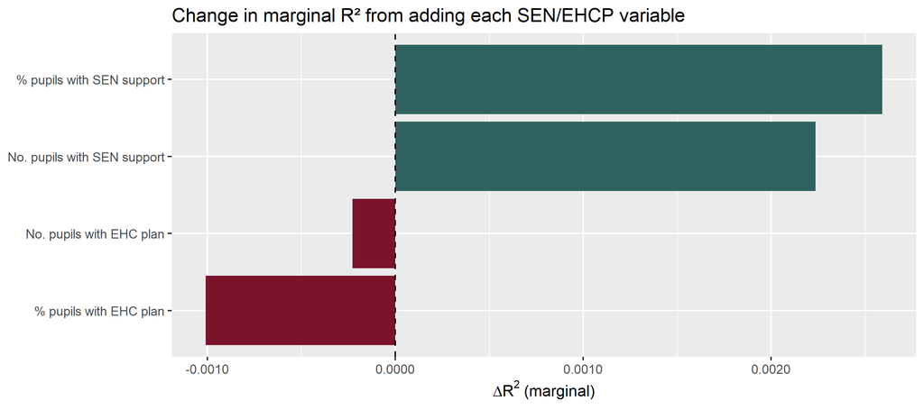

Figure 4: Change in marginal R² from adding each SEN/EHCP variable

```r
sen_results %>%
  filter(!is.na(delta_marginal)) %>%
  mutate(label = fct_reorder(label, delta_marginal)) %>%
  ggplot(aes(delta_marginal, label)) +
  geom_col(aes(fill = delta_marginal > 0), show.legend = FALSE) +
  geom_vline(xintercept = 0, linetype = "dashed") +
  scale_fill_manual(values = c(`TRUE` = "#2e6260", `FALSE` = "#7b132b")) +
  scale_x_continuous(labels = label_number(accuracy = 0.0001)) +
  labs(x = expression(Delta * R^2 ~ "(marginal)"),
       y = NULL,
       title = "Change in marginal R² from adding each SEN/EHCP variable")
```

### 11.4.3 Coefficient estimates

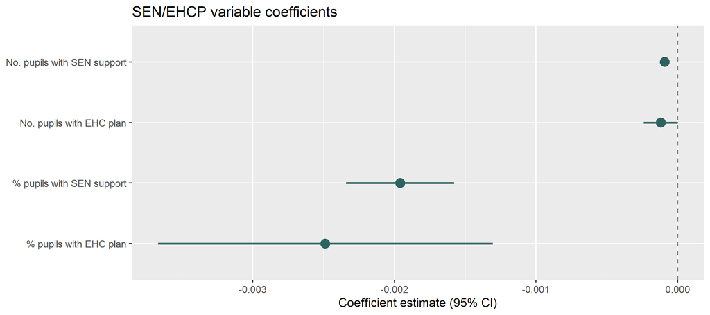

Figure 5: Coefficient estimates and 95% CIs for SEN/EHCP variable additions

```r
sen_results %>%
  filter(!is.na(coef)) %>%
  mutate(
    label = fct_reorder(label, coef),
    lower = coef - 1.96 * se,
    upper = coef + 1.96 * se
  ) %>%
  ggplot(aes(coef, label)) +
  geom_vline(xintercept = 0, linetype = "dashed", colour = "grey50") +
  geom_pointrange(aes(xmin = lower, xmax = upper), colour = "#2e6260",
                  linewidth = 0.8, size = 0.8) +
  labs(x = "Coefficient estimate (95% CI)", y = NULL,
       title = "SEN/EHCP variable coefficients")
```

## 11.5 Multi-variable SEN model

If any SEN variables are significant (p < 0.05) and improve marginal R², we fit them together.

```r
sen_sig <- sen_results %>%
  filter(p_value < 0.05, delta_marginal > 0)

cat("Significant SEN improvers:", nrow(sen_sig), "\n")
```

```
Significant SEN improvers: 2
```

```r
if (nrow(sen_sig) > 0) {
  cat("Variables:", paste(sen_sig$term, collapse = ", "), "\n")
}
```

```
Variables: PSENELK, TSENELK
```

```r
if (nrow(sen_sig) > 1) {
  multi_terms <- paste(sen_sig$term, collapse = " + ")
  fml_multi <- update(base_formula_sen, paste("~ . +", multi_terms))

  mod_sen_multi <- lmer(
    fml_multi, data = d_sen, REML = TRUE, na.action = na.exclude,
    control = lmerControl(optimizer = "bobyqa", optCtrl = list(maxfun = 20000))
  )

  r2_sen_multi <- r2(mod_sen_multi)
  cat("Multi-SEN model R² (marginal):",
      round(r2_sen_multi$R2_marginal, 4), "\n")
  cat("Multi-SEN model R² (conditional):",
      round(r2_sen_multi$R2_conditional, 4), "\n")
  cat("ΔR² marginal:",
      round(r2_sen_multi$R2_marginal - r2_sen_baseline$R2_marginal, 5), "\n")

  cat("\nCoefficients:\n")
  print(summary(mod_sen_multi)$coefficients[sen_sig$term, , drop = FALSE])
} else if (nrow(sen_sig) == 1) {
  cat("\nOnly one significant SEN variable — no multi-variable model needed.\n")
  cat("The single-variable result above is the best SEN model.\n")
} else {
  cat("\nNo SEN variables significantly improve the baseline model.\n")
}
```

```
Multi-SEN model R² (marginal): 0.6324
Multi-SEN model R² (conditional): 0.7731
ΔR² marginal: 0.00068

Coefficients:
             Estimate   Std. Error       df   t value     Pr(>|t|)
PSENELK -0.0032831261 3.297113e-04 12159.61 -9.957578 2.868785e-23
TSENELK  0.0001482161 2.979569e-05 12174.08  4.974415 6.633826e-07
```

## 11.6 SEN summary

```r
sen_summary <- tibble(
  Model = "Baseline (no SEN)",
  `R² marginal` = round(r2_sen_baseline$R2_marginal, 4),
  `R² conditional` = round(r2_sen_baseline$R2_conditional, 4)
)

# Add best single-variable result
best_single <- sen_results %>% filter(!is.na(delta_marginal)) %>%
  slice_max(delta_marginal, n = 1)

if (nrow(best_single) > 0 && best_single$delta_marginal > 0) {
  sen_summary <- bind_rows(
    sen_summary,
    tibble(
      Model = paste0("+ ", best_single$label, " (best single)"),
      `R² marginal` = round(best_single$r2_marginal, 4),
      `R² conditional` = round(best_single$r2_conditional, 4)
    )
  )
}

if (exists("mod_sen_multi") && nrow(sen_sig) > 1) {
  sen_summary <- bind_rows(
    sen_summary,
    tibble(
      Model = paste0("+ all significant SEN vars (",
                     paste(sen_sig$term, collapse = " + "), ")"),
      `R² marginal` = round(r2_sen_multi$R2_marginal, 4),
      `R² conditional` = round(r2_sen_multi$R2_conditional, 4)
    )
  )
}

sen_summary %>% kable()
```

Table 9: R² comparison: baseline vs SEN-augmented models

| Model | R² marginal | R² conditional |
| --- | --- | --- |
| Baseline (no SEN) | 0.6317 | 0.7712 |
| + % pupils with SEN support (best single) | 0.6343 | 0.7724 |
| + all significant SEN vars (PSENELK + TSENELK) | 0.6324 | 0.7731 |

**NoteSEN interpretation notes**

- The **percentage** variables (`PSENELSE`, `PSENELK`) are more interpretable than counts because they adjust for school size.
- SEN prevalence is strongly correlated with deprivation (`PTFSM6CLA1A`), so these variables may not add much beyond what FSM% already captures.
- A significant negative coefficient on `PSENELSE` (% with EHCP) would suggest that schools with more EHCP pupils have lower attainment *even after controlling for* deprivation, absence, prior attainment, and other predictors — potentially reflecting the severity of need rather than school effectiveness.
- Count variables (`TSENELSE`, `TSENELK`) may partly proxy for school size and should be interpreted with caution.

[figure not shown]

[UCL Centre for Advanced Spatial Analysis](https://www.ucl.ac.uk/bartlett/casa) · School Attainment Tool